# ANTsR TUT

Leonardo Cerliani

11 November, 2020

# Before you start

This tutorial for ANTsR is based on the Rmd [notebook by Brian Avants on antsRegistration in R](https://github.com/stnava/ANTsTutorial/blob/master/registration/antsRegistrationIntro.Rmd).

The Rmd version was evaluated riding on the Storm, but it should work everywhere.

# Read images

```r
library(ANTsR)

# Read images
r16 = antsImageRead( getANTsRData( "r16" ) )
r64 = antsImageRead( getANTsRData( "r64" ) )
```

# Visualization

## Define a function for plotting

```r
# Only one image
antsplot.single <- function(image){
  invisible(
    plot(
      image,
      doCropping = F
    )
  )
}


# Simple overlay with alpha
antsplot.olay <- function(bg, olay, alpha=0.5){
  invisible(
    plot(
      bg, olay,
      color.overlay='red',
      doCropping = F,
      alpha=alpha,
      window.overlay = quantile(olay, c(0.72,1))
    )
  )
}


# Overlay canny borders
antsplot.canny <- function(bg, olay, alpha=1){
  canned_olay = iMath(olay, "Canny", 3,3,3)
  invisible(
    plot(
      bg, canned_olay,
      color.overlay='red',
      doCropping = F,
      alpha=alpha
    )
  )
}
```

## Plot single image

```r
antsplot.single(r16)
```

[output not shown]

## Plot overlay with transparency

```r
antsplot.olay(r16,r64)
```

[output not shown]

## Plot borders of overlay

```r
antsplot.canny(r16,r64)
```

[output not shown]

# Estimate Registration

See `?antsRegistration()` for different typesofTransform

## Translation

```r
trans_reg = antsRegistration(
  fixed=r16,
  moving=r64,
  typeofTransform = 'Translation'
)

antsplot.canny(r16, trans_reg$warpedmovout)
```

[output not shown]

## Rigid registration

```r
rigid_reg = antsRegistration(
  fixed=r16,
  moving=r64,
  typeofTransform = 'Rigid'
)

antsplot.canny(r16, rigid_reg$warpedmovout)
```

[output not shown]

## Affine registration

```r
affine_reg = antsRegistration(
  fixed=r16,
  moving=r64,
  typeofTransform = 'Affine',
  verbose = F
)

antsplot.canny(r16, affine_reg$warpedmovout)
```

[output not shown]

## SyN registration

```r
syn_reg = antsRegistration(
  fixed = r16,
  moving = r64,
  typeofTransform = 'SyN'
)

antsplot.canny(r16, syn_reg$warpedmovout)
```

[output not shown]

## SyNCC registration

```r
synCC_reg = antsRegistration(
  fixed = r16,
  moving = r64,
  typeofTransform = 'SyNCC'
)

antsplot.canny(r16, synCC_reg$warpedmovout)
```

[output not shown]

# Mutual Information metric

To estimate the goodness of different kinds of registration we can plot the MI metric against the number of parameters

```r
MI <- c(
  antsImageMutualInformation( r16, r64),
  antsImageMutualInformation( r16, trans_reg$warpedmovout),
  antsImageMutualInformation( r16, rigid_reg$warpedmovout),
  antsImageMutualInformation( r16, affine_reg$warpedmovout),
  antsImageMutualInformation( r16, syn_reg$warpedmovout),
  antsImageMutualInformation( r16, synCC_reg$warpedmovout)
)

nparameters = c( 0, 2, 4, 8, 16, 32 )
plot( nparameters, MI, type='l', main='Similarity vs number of parameters' )
```

[output not shown]

# Jacobian determinant image

From Brian Avants’ notebook on antsRegistration:

“What does “differentiable map with differentiable inverse” mean? The diffeomorphism is like a road between the two images - we can go back and forth along it.

It also means that if we compose the mapping from A to B with the mapping from B to A, we get the identity.

We can check this by looking at the result of the composition of SyN’s forward and inverse maps."

## Forward warpfield

```r
grid_fw = createWarpedGrid( r16,
                            fixedReferenceImage = r16,
                            transform = syn_reg$fwdtransforms[1]
                          )

invisible(plot( grid_fw ))
```

[output not shown]

## Inverse warpfield

```r
grid_backwd = createWarpedGrid( r16,
                                 fixedReferenceImage = r16,
                                 transform = syn_reg$invtransforms[2]
                              )
invisible(plot( grid_backwd ))
```

[output not shown]

## Composition of forward and inverse

```r
emptygrid = createWarpedGrid( r16, fixedReferenceImage = r16 )

invidmap = antsApplyTransforms( r16, emptygrid,
   c( syn_reg$invtransforms, syn_reg$fwdtransforms ),
   whichtoinvert = c( T,F,F,F ))  # tricky stuff here

invisible(plot( invidmap ))
```

[output not shown]

“This “inverse identity” constraint is built into SyN such that we enforce consistency in the digital domain.

What this means is - any “shape change” is encoded losslessly into the deformation field.

**Non-diffeomorphic** maps may lose information or may be completely uninterpretable, statistically.

**One way to check this is to investigate the jacobian. They should be positive which indicates that the topology of the image space is preserved ( no folding and no holes or tears are created ).**"

```r
syn_reg_jac = createJacobianDeterminantImage( r16,
                                              syn_reg$fwdtransforms[1],
                                              geom = TRUE,
                                              doLog = T)

synCC_reg_jac = createJacobianDeterminantImage( r16,
                                                synCC_reg$fwdtransforms[1],
                                                geom = TRUE,
                                                doLog = T)
```

# Is there a difference between the two jacobians? Paired t-test.

```r
mask = getMask( r16 ) %>% morphology("dilate",3)
print( t.test( syn_reg_jac[ mask == 1 ], synCC_reg_jac[ mask == 1], paired=TRUE  ) )
```

[output not shown]

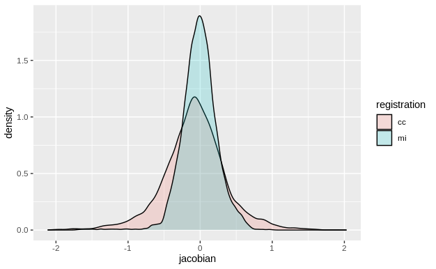

```r
library( ggplot2 )

n = sum( mask == 1)

# SyN uses MI, SyNCC uses CC
mydf = data.frame(
  registration = c( rep( "cc", n ) , rep("mi", n ) ),
  jacobian = c( synCC_reg_jac[ mask == 1 ], syn_reg_jac[ mask == 1] ) )

ggplot( mydf, aes(jacobian, fill=registration )) + geom_density(alpha = 0.2)
```

```r
NA
NA
```

## You can also visualize the jacobian determinant image

```r
antsplot.single(syn_reg_jac)
antsplot.single(synCC_reg_jac)
```

[output not shown]